# Evaluating classification models (Notes)

Stat 253

Author

# Learning Goals

- Calculate (by hand from confusion matrices) and contextually interpret overall accuracy, sensitivity, and specificity
- Construct and interpret plots of predicted probabilities across classes
- Explain how a ROC curve is constructed and the rationale behind AUC as an evaluation metric
- Appropriately use and interpret the no-information rate to evaluate accuracy metrics

# Notes: Classification Evaluation

**CONTEXT**

- **world = supervised learning**  
  We want to model some output variable $y$ using a set of potential predictors ($x_1, x_2, ..., x_p$).
- **task = CLASSIFICATION**  
  $y$ is categorical and **binary**
- **(parametric) algorithm**  
  logistic regression
- **application = classification**
  - Use our algorithm to calculate the probability that y = 1.
  - Turn these into binary classifications using a classification rule. For some probability threshold c:
    - If the probability that y = 1 is at least c, classify y as 1.
    - Otherwise, classify y as 0.
  - WE get to pick c. This should be guided by *context* (what are the consequences of misclassification?) and the *quality* of the resulting classifications.

**GOAL**

*Evaluate* the quality of binary classifications of $y$ (here resulting logistic regression model).

## Sensitivity & specificity

$$\begin{split}
\text{overall accuracy} & = \text{probability of making a correct classification} \\
\text{sensitivity} & = \text{true positive rate}\\
& = \text{probability of correctly classifying $y=1$ as $y=1$} \\
\text{specificity} & = \text{true negative rate} \\
& = \text{probability of correctly classifying $y=0$ as $y=0$} \\
\text{1 - specificity} & = \text{false positive rate} \\
& = \text{probability of classifying $y=0$ as $y=1$} \\
\end{split}$$

**In-sample estimation** (how well our model classifies the same data points we used to build it)

|  | y = 0 | y = 1 |
| --- | --- | --- |
| classify as 0 | a | b |
| classify as 1 | c | d |

$$\begin{split}
\text{overall accuracy} & = \frac{a + d}{a + b + c + d}\\
\text{sensitivity} & = \frac{d}{b + d} \\
\text{specificity} & = \frac{a}{a + c} \\
\end{split}$$

**k-Fold Cross-Validation** (how well our model classifies NEW data points)

- Divide the data into k folds of approximately equal size.
- Repeat the following procedures for each fold j = 1, 2, …, k:
  - Remove fold j from the data set.
  - Fit a model using the other k - 1 folds.
  - Use this model to classify the outcomes for the data points in fold j.
  - Calculate the overall accuracy, sensitivity, and specificity of these classifications.
- Average the metrics across the k folds. This gives our CV estimates of overall accuracy, sensitivity, and specificity.

## ROC curves (receiver operating characteristic curves)

Sensitivity and specificity depend upon the *specific* probability threshold c.

- If we lower c, hence make it *easier* to classify y as 1: sensitivity increases *but* specificity decreases
- If we increase c, hence make it *tougher* to classify y as 1: specificity increases *but* sensitivity decreases

To understand this trade-off, for a *range* of possible thresholds c between 0 and 1, ROC curves calculate and plot

- y-axis: sensitivity (true positive rate)
- x-axis: 1 - specificity (false positive rate)  
  Since specificity is the probability of classifying y = 0 as 0, 1 - specificity is the misclassifying y = 0 as 1.

Why we care:

- Along with context, ROC curves can help us identify an appropriate probability threshold c.
- ROC curves can help us compare the quality of different models.
- The **area under an ROC curve** (AUC) estimates the probability that our algorithm is *more* likely to classify y = 1 as 1 than to classify y = 0 as 1, hence distinguish between the 2 classes. Put another way: if we give our model 2 data points, one with y = 0 and the other with y = 1, AUC is the probability that we correctly identify which is which.

# Small Group Discussion

## EXAMPLE 1

Suppose we model `RainTomorrow` in Sydney using only the number of hours of bright `Sunshine` today. Using a **probability threshold of 0.5**, this model produces the following **classification rule**:

- If `Sunshine` < 3.125, predict rain.
- Otherwise, predict no rain.

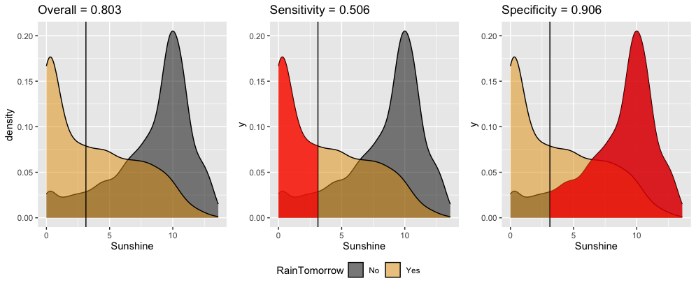

Interpret these **in-sample** *estimates* of the resulting classification quality.

1. Overall accuracy = 0.803
   - We correctly predict the rain outcome (yes or no) 80.3% of the time.
   - We correctly predict “no rain” on 80.3% of non-rainy days.
   - We correctly predict “rain” on 80.3% of rainy days.
2. Sensitivity = 0.506
   - We correctly predict the rain outcome (yes or no) 50.6% of the time.
   - We correctly predict “no rain” on 50.6% of non-rainy days.
   - We correctly predict “rain” on 50.6% of rainy days.
3. Specificity = 0.906
   - We correctly predict the rain outcome (yes or no) 90.6% of the time.
   - We correctly predict “no rain” on 90.6% of non-rainy days.
   - We correctly predict “rain” on 90.6% of rainy days.

## OPTIONAL EXTRA PRACTICE

Confirm the 3 metrics above using the confusion matrix. Work is shown below (peek when you’re ready).

```
            Truth
Prediction   No  Yes
       No  3108  588
       Yes  324  602
```

```r
# Overall accuracy
(3108 + 602) / (3108 + 602 + 324 + 588)
## [1] 0.8026828

# Sensitivity
602 / (602 + 588)
## [1] 0.5058824

# Specificity
3108 / (3108 + 324)
## [1] 0.9055944
```

## EXAMPLE 2: ROC curves

We can change up the probability threshold in our classification rule! The ROC curve for our logistic regression model of `RainTomorrow` by `Sunshine` plots the sensitivity (true positive rate) vs 1 - specificity (false positive rate) corresponding to “every” possible threshold:

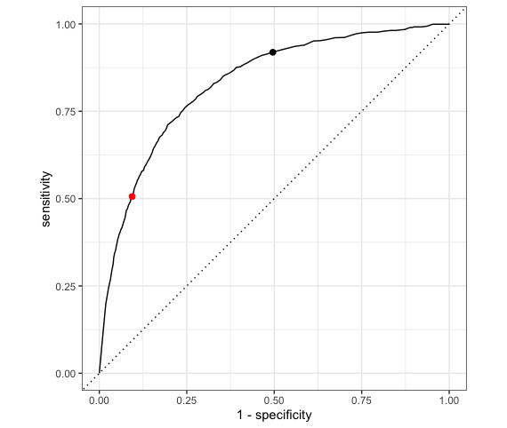

1. Which point represents the quality of our classification rule using a 0.5 probability threshold?
2. The other point corresponds to a different classification rule which uses a different threshold. Is that threshold smaller or bigger than 0.5?
3. Which classification rule do you prefer?

**EXAMPLE 3: Area Under the ROC Curve (AUC)**

The **area under an ROC curve** (AUC) estimates the probability that our algorithm is *more* likely to classify y = 1 (rain) as 1 (rain) than to classify y = 0 (no rain) as 1 (rain), hence distinguish between the 2 classes. AUC is helpful for evaluating and comparing the overall quality of classification models. Consider 3 different possible predictors (A, B, C) of rainy and non-rainy days:

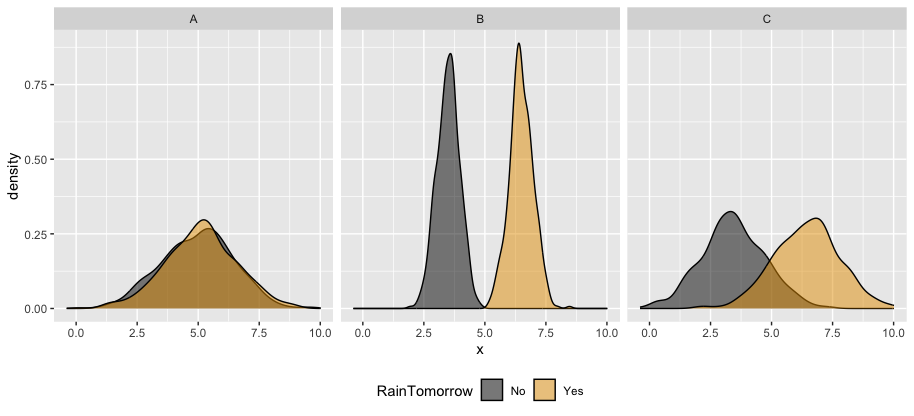

The ROC curves corresponding to the models `RainTomorrow ~ A`, `RainTomorrow ~ B`, `RainTomorrow ~ C` are shown below.

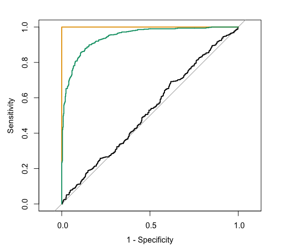

For each ROC curve, indicate the corresponding model and the approximate AUC. Do this in any order you want!

**black ROC curve**

- `RainTomorrow ~ ___`
- AUC is roughly ___

**green ROC curve**

- `RainTomorrow ~ ___`
- AUC is roughly ___.

**orange ROC curve**

- `RainTomorrow ~ ___`
- AUC is exactly ___.

## AUC OBSERVATIONS

In general:

- A *perfect* classification model has an AUC of 1.
- The *simplest* classification model that just randomly predicts y to be 1 or 0 (eg: by flipping a coin), has an AUC of 0.5. It is represented by the diagonal “no discrimination line” in an ROC plot.
- A model with an AUC below 0.5 is *worse* than just random. Flipping a coin would be better.

# Exercises

Today’s in-class exercises will be due as HW4. Please find the exercises and template on Moodle. I recommend working on Exercises 1, 5, and 6 in class. Exercise 1 is necessary to the other exercises, and Exercises 5 and 6 involve new content: ROC curves, AUC, and LASSO for classification!

# Notes: R code

Let `my_model` be a logistic regression model of categorical response variable `y` using predictors `x1` and `x2` in our `sample_data`.

```r
# Load packages
library(tidymodels)

# Resolves package conflicts by preferring tidymodels functions
tidymodels_prefer()
```

```r
# Calculate the probability that y = 1 for each sample data point
# The probability is stored in the .pred_Yes column
in_sample_predictions <- my_model %>%
  augment(new_data = sample_data)
```

```r
# Plot the predicted probability that y = 1 by the actual y category
ggplot(in_sample_predictions, aes(y = .pred_Yes, x = y)) +
  geom_boxplot()
```

```r
# Calculate sensitivity & specificity for a range of probability thresholds
in_sample_predictions %>%
  roc_curve(truth = y, .pred_Yes, event_level = "second")

# Plot the ROC curve
in_sample_predictions %>%
  roc_curve(truth = y, .pred_Yes, event_level = "second") %>%
  autoplot()

# Calculate the AUC
in_sample_predictions %>%
  roc_auc(truth = y, .pred_Yes, event_level = "second")
```